# Question 1

## 1a

```r
library(tidyverse)

# Reading data and recode
heart <- read.csv("data/saheart.csv")
heart$famhist <- factor(heart$famhist, levels = c("Absent", "Present"))
X <- data.frame(heart[, names(heart) != "chd"])
y <- heart$chd
X <- X %>% mutate(famhist12 = ifelse(famhist == "Present", 2, 1)) %>% select(-famhist) %>% rename(famhist = famhist12) %>% data.matrix()

# Prior probabilities
pi.no <- sum(y == 0)/nrow(X)
pi.yes <- sum(y == 1)/nrow(X)

# Mean vectors
centroid.no <- colMeans(X[y == 0, ])
centroid.yes <- colMeans(X[y == 1, ])

# Pooled variance matrix
X.no.centered <- sweep(X[y == 0, , drop = FALSE], 2, centroid.no, "-")
X.yes.centered <- sweep(X[y == 1, , drop = FALSE], 2, centroid.yes, "-")
Sigma <- (crossprod(X.no.centered) + crossprod(X.yes.centered)) / (nrow(X) - 2)
```

## 1b

```r
Sigma.inv <- solve(Sigma)

score.no <- drop(X %*% Sigma.inv %*% centroid.no) -
  0.5 * drop(t(centroid.no) %*% Sigma.inv %*% centroid.no) + log(pi.no)
score.yes <- drop(X %*% Sigma.inv %*% centroid.yes) -
  0.5 * drop(t(centroid.yes) %*% Sigma.inv %*% centroid.yes) + log(pi.yes)

# Each prediction corresponds to the same row in X; ties go to class 0.
prediction <- as.integer(score.yes > score.no)

# Class 1 is positive; class 0 is negative.
tabq1b <- table(y, prediction, dnn = list("Predicted", "Actual"))
tabq1b
```

```
         Actual
Predicted   0   1
        0 258  44
        1  73  87
```

```r
sum(tabq1b) == nrow(X)
```

```
[1] TRUE
```

The dimension in the matrix match that of the vector.

## 1c

```r
library(MASS)
lda_pred <- lda(y ~ ., data = data.frame(X, y), CV = TRUE)
table(lda_pred$class, y)
```

```
   y
      0   1
  0 256  79
  1  46  81
```

The result of the prediction slightly differs from the manual LDA implementation.

# Question 2

## 2a

```r
zip.train <- read_csv("data/zip-train.csv.gz", col_names = FALSE)
zip.test <- read_csv("data/zip-test.csv.gz", col_names = FALSE)

# Select 40 predictors
pred_var <- apply(zip.train[, -1], 2, var)
top40pred.index <- order(pred_var, decreasing = TRUE)[1:40]

# Prepare prediction variables
q2y <- zip.test[, 1,drop = TRUE]
top40pred <- zip.test[, top40pred.index + 1] #bc index excludes y column

qda_top40_pred <- qda(q2y ~ ., data = data.frame(top40pred, q2y), CV = TRUE)
conf.tab_40pred <- table(qda_top40_pred$class, q2y)
miss.rate_40pred <- 1 - sum(diag(conf.tab_40pred)) / sum(conf.tab_40pred)

conf.tab_40pred
```

```
   q2y
      0   1   2   3   4   5   6   7   8   9
  0 322   1   7   4   0  12   1   1   1   0
  1   0 236   0   0   1   0   0   0   0   0
  2  19   2 164   4  10   5   6   9   9   1
  3   5   0   9 137   0   9   0   2  12   1
  4   2  15   6   0 150   1   2   8   2  15
  5   3   0   2   7   1 121   5   0   2   1
  6   1   5   1   0   0   1 149   0   0   1
  7   0   0   0   0   2   0   0 116   0   5
  8   7   5   9  14  10  10   7   3 140  10
  9   0   0   0   0  26   1   0   8   0 143
```

```r
miss.rate_40pred
```

```
[1] 0.1639263
```

## 2b

Yes. The method works quite well. We select 40 predictors with the highest variance. Predictors with high variances are more likely to be informative for classification as they have more variability and more potential to distinguish between classes. For instance, a pixel at the corner may remain white for all classes. It may be less informative for distinguishing between classes. Other pixels near the center may have more variation and thus be more useful for classification.

## 2c

```r
top10pred.index <- order(pred_var, decreasing = TRUE)[1:10]

# Prepare prediction variables
q2y <- zip.test[, 1,drop = TRUE]
top10pred <- zip.test[, top10pred.index + 1] #bc index excludes y column

qda_top10_pred <- qda(q2y ~ ., data = data.frame(top10pred, q2y), CV = TRUE)
conf.tab_10pred <- table(qda_top10_pred$class, q2y)
miss.rate_10pred <- 1 - sum(diag(conf.tab_10pred)) / sum(conf.tab_10pred)

conf.tab_10pred
```

```
   q2y
      0   1   2   3   4   5   6   7   8   9
  0 300   1  20   5   0  16  59   3   1   0
  1   0 240   0   0   6   0   0   1   2   2
  2  14   5  88   9   9   8  18   4  12  10
  3   6   1  10 112   0  47   6   0  32   1
  4   3   6  16   4  90   5   2   5  16  21
  5  12   0   3  27   1  74  11   0  10   0
  6  19   1  21   0   4   4  59   2   5   0
  7   5   0  27   0  13   2   8 123   0  18
  8   0   3   7   9  17   4   5   1  74   8
  9   0   7   6   0  60   0   2   8  14 117
```

```r
miss.rate_10pred
```

```
[1] 0.363727
```

The misclassification rates are worse compared to the model using the top 40 predictors. As we reduce the number of predictors, we lose information that could be useful for classification, leading to a decrease in performance. Explaining it with bias variance trade-off, reducing the number of predictors increases bias, which can lead to higher misclassification rates.

# Question 3

```r
# Set up
rho_grid <- c(0, .2, .4, .6, .8, .9)
mu.1 <- c(-1, 0, rep(0, 8))
mu.2 <- c(1, 0, rep(0, 8))
Sigma.1 <- Sigma.2 <- diag(10)
train <- array(NA, dim = c(200, 10, length(rho_grid)))
test <- array(NA, dim = c(2000, 10, length(rho_grid)))
test.pred <- array(NA, dim = c(2000, length(rho_grid), 2))

# Generate data and predict
for (i in seq(rho_grid)){
  # Covariance matrices
  rho <- rho_grid[i]
  Sigma.1[2, 1]<- Sigma.1[1, 2] <- rho
  Sigma.2[2, 1]<- Sigma.2[1, 2] <- -1 * rho

  # Simulate data for both classes
  train.1 <- mvrnorm(100, mu.1, Sigma.1)
  train.2 <- mvrnorm(100, mu.2, Sigma.2)
  test.1 <- mvrnorm(1000, mu.1, Sigma.1)
  test.2 <- mvrnorm(1000, mu.2, Sigma.2)

  # Store simulated data
  train[,,i] <- rbind(train.1, train.2)
  test[,,i] <- rbind(test.1, test.2)


  # Run LDA QDA
  lda_mod <- lda(x = train[,,i], grouping = factor(rep(c(1, 2), each = 100)))
  qda_mod <- qda(x = train[,,i], grouping = factor(rep(c(1, 2), each = 100)))
  lda_pred <- predict(lda_mod, newdata = data.frame(test[,,i]))$class
  qda_pred <- predict(qda_mod, newdata = data.frame(test[,,i]))$class
  test.pred[,i,] <- cbind(lda_pred, qda_pred)
}

# Calculate misclassification rates
qda_miss.rate <- lda_miss.rate <- numeric(length(rho_grid))

for (i in seq(rho_grid)){
  lda_miss.rate[i] <- table(test.pred[,i,1], rep(c(1, 2), each = 1000)) %>%
    {1 - sum(diag(.)) / sum(.)}
  qda_miss.rate[i] <- table(test.pred[,i,2], rep(c(1, 2), each = 1000)) %>%
    {1 - sum(diag(.)) / sum(.)}
}
cbind(rho_grid, lda_miss.rate, qda_miss.rate)
```

```
     rho_grid lda_miss.rate qda_miss.rate
[1,]      0.0        0.1500        0.2085
[2,]      0.2        0.1790        0.2015
[3,]      0.4        0.1600        0.1850
[4,]      0.6        0.1665        0.1660
[5,]      0.8        0.1670        0.1365
[6,]      0.9        0.1515        0.1020
```

## 3b

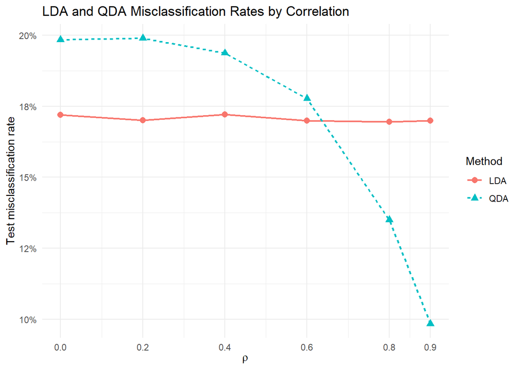

```r
# Set up
rep = 50
lda.test.pred <- array(NA, dim = c(2000, length(rho_grid), rep))
qda.test.pred <- array(NA, dim = c(2000, length(rho_grid), rep))

# Generate data and predict
for (i in seq(rho_grid)){
  # Covariance matrices
  rho <- rho_grid[i]
  Sigma.1[2, 1]<- Sigma.1[1, 2] <- rho
  Sigma.2[2, 1]<- Sigma.2[1, 2] <- -1 * rho

  for (r in seq(rep)){
    # Simulate data for both classes
    train.1 <- mvrnorm(100, mu.1, Sigma.1)
    train.2 <- mvrnorm(100, mu.2, Sigma.2)
    test.1 <- mvrnorm(1000, mu.1, Sigma.1)
    test.2 <- mvrnorm(1000, mu.2, Sigma.2)

    # Store simulated data
    train <- rbind(train.1, train.2)
    test <- rbind(test.1, test.2)

    # Run LDA QDA
    lda_mod <- lda(x = train, grouping = factor(rep(c(1, 2), each = 100)))
    qda_mod <- qda(x = train, grouping = factor(rep(c(1, 2), each = 100)))
    lda_pred <- predict(lda_mod, newdata = data.frame(test))$class
    qda_pred <- predict(qda_mod, newdata = data.frame(test))$class
    lda.test.pred[,i,r] <- lda_pred
    qda.test.pred[,i,r] <- qda_pred
  }
}

# Calculate misclassification rates
qda_miss.rate <- lda_miss.rate <- numeric(length(rho_grid))

for (i in seq(rho_grid)){
  lda_miss.rate[i] <- table(lda.test.pred[,i,], rep(rep(c(1, 2), each = 1000), rep)) %>% {1 - sum(diag(.)) / sum(.)}
  qda_miss.rate[i] <- table(qda.test.pred[,i,], rep(rep(c(1, 2), each = 1000), rep)) %>% {1 - sum(diag(.)) / sum(.)}
}
plotdata <- cbind(rho_grid, lda_miss.rate, qda_miss.rate)

# Reshape the rates into one column, with a label for each method.
plotdata_long <- as.data.frame(plotdata) %>%
  pivot_longer(
    cols = c(lda_miss.rate, qda_miss.rate),
    names_to = "method",
    values_to = "misclassification_rate"
  ) %>%
  mutate(method = ifelse(method == "lda_miss.rate", "LDA", "QDA"))

ggplot(plotdata_long,
       aes(x = rho_grid, y = misclassification_rate,
           color = method, shape = method, linetype = method)) +
  geom_line(linewidth = 0.8) +
  geom_point(size = 2.5) +
  scale_x_continuous(breaks = rho_grid) +
  scale_y_continuous(labels = scales::label_percent(accuracy = 1)) +
  labs(
    title = "LDA and QDA Misclassification Rates by Correlation",
    x = expression(rho),
    y = "Test misclassification rate",
    color = "Method", shape = "Method", linetype = "Method"
  ) +
  theme_minimal()
```

## 3c

As the correlation between the features increases, QDA tends to perform better than LDA. This is not surprising as QDA allows for different covariance matrices for each class, while LDA assumes equal covariance matrices. When the correlation is high, the true covariance structure between the two classes differs significantly, making LDA’s assumption less valid.

The phenomenon can be explained using the bias-variance trade-off. When the true covariance structure is similar for both classes, the two covariance matrices estimated by QDA for each class will capture the random noise in the data generation. The high variance of these estimates leads to a higher misclassification rate than LDA in this scenario. On the other hand, when the correlation is high, LDA’s assumption of equal covariance matrices introduces bias, which can lead to higher misclassification rates.

The eight covariates that are not relevant to the response variable can still affect the performance. The random noise from these irrelevant features can increase the variance of the covariance matrix estimates in QDA, leading to a higher misclassification rate compared to LDA.

# Question 4

## Report

### SAheart: LDA/QDA prediction analysis

#### Data and procedure

- **Variables:** `sbp`, `typea`, `age`: integer; `tobacco`, `ldl`, `adiposity`, `obesity`, `alcohol`: numeric; `famhist`: character (categorical); `chd` **(outcome)**: integer.
- **Missing value:** no.
- **Recoding:** `famhist`: Absent = 1, Present = 2; `chd`: factor levels 0 and 1 (positive class = 1).
- **CV:** Random seed **43207**; stratified training set of **369** observations (241 negatives, 128 positives) and reserved testing set of **93** (61 negatives, 32 positives). All candidates used the same stratified **10-fold CV**. Each iteration fitted preprocessing and the model on nine folds, then calculated held-out accuracy, misclassification rate, and a confusion matrix. Variance selection and centered, unit-scaled PCA were estimated within each training fold; priors used that fold’s training class frequencies. Selection minimized mean fold error, with ties favoring fewer dimensions, then LDA.
- **Compared models:** Traditional LDA/QDA with all nine predictors; LDA/QDA with the five highest raw-variance predictors; and LDA/QDA with 2, 4, or 6 leading standardized PCs (**10 candidates**). No rows were removed or values imputed.

#### Results

Accuracy is the mean across held-out CV folds. Confusion counts are **mean fold counts (SE)**, with class 1 positive.

| Model | Predictors | CV accuracy (%) | TN (SE) | FP (SE) | FN (SE) | TP (SE) |
| --- | --- | --- | --- | --- | --- | --- |
| LDA | All nine | 69.40 | 19.70 (0.72) | 4.40 (0.73) | 6.90 (0.53) | 5.90 (0.53) |
| QDA | All nine | 68.57 | 18.80 (0.65) | 5.30 (0.67) | 6.30 (0.58) | 6.50 (0.58) |
| LDA | Top five by variance | 64.21 | 19.30 (1.01) | 4.80 (0.96) | 8.40 (0.83) | 4.40 (0.81) |
| QDA | Top five by variance | 67.49 | 19.30 (0.72) | 4.80 (0.71) | 7.20 (0.51) | 5.60 (0.45) |
| LDA | Two PCs | 66.36 | 20.30 (0.76) | 3.80 (0.73) | 8.60 (0.67) | 4.20 (0.68) |
| QDA | Two PCs | 68.30 | 20.80 (0.90) | 3.30 (0.92) | 8.40 (0.43) | 4.40 (0.34) |
| **LDA** | **Four PCs (selected)** | **72.12** | **20.50 (0.58)** | **3.60 (0.62)** | **6.70 (0.62)** | **6.10 (0.62)** |
| QDA | Four PCs | 71.01 | 19.90 (0.78) | 4.20 (0.81) | 6.50 (0.56) | 6.30 (0.56) |
| LDA | Six PCs | 70.22 | 20.10 (0.72) | 4.00 (0.73) | 7.00 (0.63) | 5.80 (0.61) |
| QDA | Six PCs | 71.55 | 19.80 (0.65) | 4.30 (0.67) | 6.20 (0.68) | 6.60 (0.70) |

**Reading the counts:** TN, FP, FN, and TP correspond to actual/predicted classes 0/0, 0/1, 1/0, and 1/1. Each fold averaged 36.9 held-out observations. SE = sample SD of fold counts divided by $\sqrt{10}$. These SEs are descriptive: training sets overlap, and held-out fold sizes and class composition vary. They are not independent-sample confidence intervals. All fits succeeded.

#### Selected model and estimated prediction error

1. **Chosen model:** LDA with four standardized principal components.
2. **Refitting and application:** After locking selection, centered, unit-scaled PCA and LDA were refitted on the **whole training set (369 observations)**. The four PCs explain **67.6%** of training predictor variance. The refitted pipeline was applied once to the **reserved testing set (93 observations)**.
3. **Testing performance:** Misclassification rate = **20/93 = 21.51%**; classification accuracy = **73/93 = 78.49%**.
4. **Testing confusion counts and error types:** Class 0 is negative; class 1 is positive. In **TN, FP, FN, TP** order, the counts are **56, 5, 15, 17**.

   | Measure | Calculation | Rate |
   | --- | --- | --- |
   | Type I error (false positive) | FP / (TN + FP) = 5/61 | **8.20%** |
   | Type II error (false negative) | FN / (FN + TP) = 15/32 | **46.88%** |

#### Main findings and limitations

Four-PC LDA reduced mean CV error relative to ordinary LDA (**30.60%**) and QDA (**31.43%**). Its lead over six-PC QDA (**28.45%**) is small and does not establish superiority. Raw-variance subsets performed worse, and their rankings depend on measurement units.

The selected classifier missed **15 of 32 positive test cases**. Class imbalance, only 93 test observations, CV selection optimism, and Gaussian assumptions for skewed or binary predictors limit conclusions. This rerun reuses the previously evaluated split, so it is not new independent validation. Independence is assumed; performance in other populations may differ.

Explicitly invoked skill: `$lda-qda-analysis`. Reproducible R code and complete analysis output include the fold results and preprocessing audit; test predictions are also available.

## ## Skill

name: lda-qda-analysis description: Compare LDA/QDA classifiers with CV and a one-page report. —

# LDA QDA analysis

## Rules

- At most 10 candidate configurations, including ordinary LDA and QDA on all usable original covariates. Count each classifier/representation/dimension, including failures; exclude fold fits and final refit.
- Report every data change, reason, affected variables/counts and recoding mappings/levels. Keep a reproducible record; summarize changes in report. State when none.
- Report <=1 A4 page total. Render/check pagination; Markdown alone cannot verify it. Reference code/diagnostics/overflow tables in analysis artifact. Disclose unavailable results, failures or incomplete CV.

## 1. Explore and prepare

Identify outcome/predictors; ask if unclear. Inspect dimensions, types, rows, summaries, classes, distributions, outliers, duplicates and missingness counts/patterns/codes.

If missingness exists, ask: “Is at least missing at random (MAR) reasonable: missingness may depend on observed information, but not on missing values conditional on observed information?” Explain that MCAR is stronger and observed data alone cannot establish MAR. Wait before treatment; continue exploration. No automatic deletion/imputation; MAR alone does not justify treatment.

Recode outcome as factor/categorical; preserve labels/missing labels, record levels/positive class, check unintended NAs. Summarize exploration/questions.

## 2. Compare models

Reserve test data before fitting; honor existing splits. Choose 5, 10 or 20 folds; stratify independent observations or use group/time splits. Share training-only folds across candidates. Check fold feasibility; ask if no allowed count works. Record seed, priors, warnings/failures.

Fit ordinary LDA/QDA on all usable covariates. Check constants/dependence/covariance rank; QDA needs more training cases per class than predictors and full-rank class covariance. Report infeasibility, no silent substitution.

For many covariates, try LDA/QDA with high-variance subsets or leading PCs at several dimensions. Record variables/variances, PCA centering/scaling and explained variance. Variance depends on units; standardized variances cannot rank features. High variance/PCs need not separate classes.

Fit imputation/selection/scaling/PCA/embedding only within fold training; apply to held-out cases. Exclude outcome from selection/PCA. Record each fold’s held-out accuracy/error/full matrix, predictions and preprocessing.

Select lowest mean fold error (=1-mean fold accuracy), not pooled accuracy; declare ties. Lock choice, refit selected pipeline on all training data, evaluate once on test. No test-based tuning; selection CV can be optimistic.

## 3. Report

### Data and procedure: list with these headings

- **Variables:** Original predictor names/types; outcome name followed by **(outcome)** and original type.
- **Missing value:** **no**, or briefly describe affected variables and treatment.
- **Recoding:** Only recoded variables and mappings, including outcome levels.
- **CV:** Seed, training/testing sizes, fold count, split handling, shared folds, fold-fitted preprocessing and each iteration’s accuracy/error/matrix calculation. No fold-count rationale.
- **Compared models:** Briefly describe every candidate (all 10 if tried), including ordinary LDA/QDA, dimensions and variance/PCA procedure.

### Results

Table: each candidate’s mean fold accuracy (%), no training metrics/matrices. Binary confusion cells: TN, FP, FN, TP as decimal mean fold counts with SE = sample SD of fold counts / sqrt(k). Multiclass: same mean/SE for every cell, including zeros; rows actual, columns predicted, stable labeled class order. Label mean fold counts, not pooled totals. SEs are descriptive: folds vary in size/composition and overlap in training, so no independent confidence intervals. Retain full outputs in artifact.

### Selected model and estimated prediction error: numbered list

1. **Chosen model:** Classifier and representation/dimension; no repeated CV error.
2. **Refitting and application:** Refit preprocessing/model on whole training set, then apply once to reserved testing set; no training performance.
3. **Testing performance:** Error and accuracy percentages with incorrect/total and correct/total counts.
4. **Testing confusion matrix and error types:** State negative/positive classes; explicitly label integer counts in TN, FP, FN, TP order. Type I (false positive) = FP/(TN+FP); Type II (false negative) = FN/(FN+TP). Give percentages and counts; zero denominator means undefined. Multiclass: full labeled matrix and per-class one-versus-rest rates. If testing labels unavailable, mark metrics unavailable, not CV-as-test.

### Main findings and limitations

Explain preference, reduction effects, class errors and limitations: size, imbalance, assumptions, stability/generalization. Note selection optimism; small differences do not prove superiority.

## Explanation

The skill is 5 kb. I mostly include instruction on the procedure for fitting and evaluating LDA/QDA models with cross-validation. I explicitly state the models that I want my AI to try out and include in its analysis. I also state the CV procedure and prediction error estimation procedures. Also, I explicitly state the evaluation criteria and things to include in the report.

I also include a lot of the format requirement. I ask my AI to include key information in the report such as mean CV accuracy and SE for each candidate model. Including this information allow the reader to spot any mistakes that AI might make. I explicitly ask AI to present the result mostly in list format to allow easy reading.

The report above is adjusted so that it’s easier to read after rendered to html format.